Python 3.6.7 |Anaconda, Inc.| (default, Oct 28 2018, 19:44:12) [MSC v.1915 64 bit (AMD64)]

Type "copyright", "credits" or "license" for more information.

IPython 6.5.0 -- An enhanced Interactive Python.

Restarting kernel...

In [1]: runfile('E:/University_of_Florida/11th term/Statistical Machine Learning/Project/purchase-prediction/purchase-reg-models-gridCV.py', wdir='E:/University_of_Florida/11th term/Statistical Machine Learning/Project/purchase-prediction')

Importing libraries.......

Exporting data.......

<class 'pandas.core.frame.DataFrame'>

RangeIndex: 550068 entries, 0 to 550067

Data columns (total 12 columns):

User_ID 550068 non-null int64

Product_ID 550068 non-null object

Gender 550068 non-null object

Age 550068 non-null object

Occupation 550068 non-null int64

City_Category 550068 non-null object

Stay_In_Current_City_Years 550068 non-null object

Marital_Status 550068 non-null int64

Product_Category_1 550068 non-null int64

Product_Category_2 376430 non-null float64

Product_Category_3 166821 non-null float64

Purchase 550068 non-null int64

dtypes: float64(2), int64(5), object(5)

memory usage: 50.4+ MB

Data Preprocessing.......

Regression Model Training.......

Multiple Linear Regression

Training and Testing Performance Report

Train RMSE : 4381

Test RMSE : 4365

CV Score : Mean - 4381 | Std - 13.42

Decision Tree Regression

Fitting 3 folds for each of 8 candidates, totalling 24 fits

[Parallel(n_jobs=1)]: Using backend SequentialBackend with 1 concurrent workers.

[Parallel(n_jobs=1)]: Done 24 out of 24 | elapsed: 24.8s finished

0.6993336829333154

DT Train RMSE : 2698

DT Test RMSE : 2746

Random Forest Regression

Fitting 3 folds for each of 18 candidates, totalling 54 fits

[Parallel(n_jobs=1)]: Using backend SequentialBackend with 1 concurrent workers.

[Parallel(n_jobs=1)]: Done 54 out of 54 | elapsed: 2.8min finished

0.7075660672647061

RF Train RMSE : 2616

RF Test RMSE : 2708

Extreme Gradient Boosting Decision Tree Regression

Fitting 3 folds for each of 60 candidates, totalling 180 fits

[Parallel(n_jobs=1)]: Using backend SequentialBackend with 1 concurrent workers.

[Parallel(n_jobs=1)]: Done 180 out of 180 | elapsed: 563.0min finished

0.7472936977981175

XGB Train RMSE : 2009

XGB Test RMSE : 2518

Model prediction graphs.......

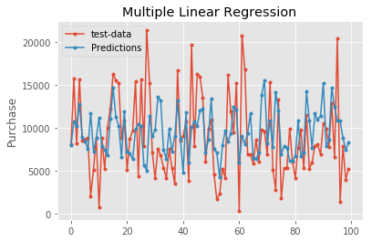

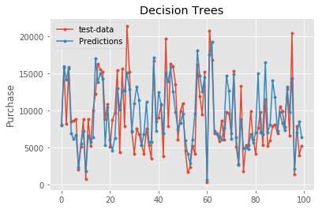

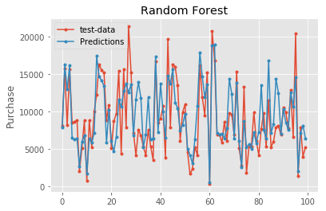

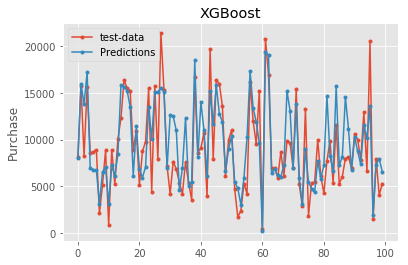

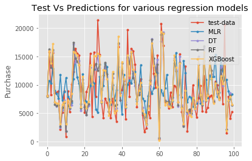

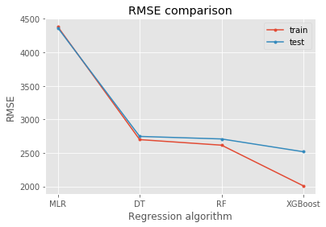

In [2]: